# Introduction to Supervised Classification

#### Learning Rate

We'll briefly consider how different learning rates are effecting the deep neural network.

```python
%%time
# Create instance of the deep network
network_d2 = NeuralNetDeep(input_size, hidden_size_d, num_classes)

# Calculate losses and accuracies for a network with learning rate 0.0005
loss_d2, accuracies_d2, _ = neural_network_training(
    network_deep,
    learning_rate = 0.0005,
    batch_size = 64,
    print_loss_values = False,
    split_and_test = True
)
```

```
CPU times: user 10.3 s, sys: 324 ms, total: 10.7 s
Wall time: 10.8 s
```

```python
%%time
# Create instance of the deep network
network_d3 = NeuralNetDeep(input_size, hidden_size_d, num_classes)

# Calculate losses and accuracies for a network with learning rate 0.0005
loss_d3, accuracies_d3, _ = neural_network_training(
    network_d3,
    learning_rate = 0.95,
    batch_size = 64,
    print_loss_values = False,
    split_and_test = True
)
```

```
CPU times: user 10.4 s, sys: 270 ms, total: 10.7 s
Wall time: 10.8 s
```

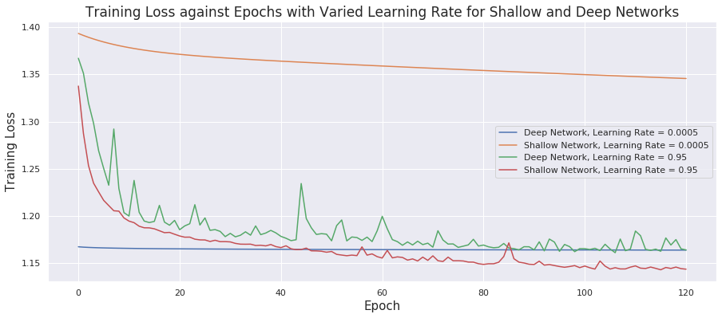

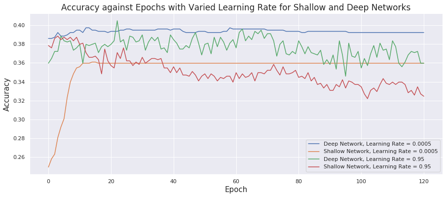

```python
# Plot the loss values against epochs
plot_stats(
    [loss_d2, loss_2, loss_d3, loss_4],
    ['Deep Network, Learning Rate = 0.0005',
     'Shallow Network, Learning Rate = 0.0005',
     'Deep Network, Learning Rate = 0.95',
     'Shallow Network, Learning Rate = 0.95'
     ],
    'Training Loss against Epochs with Varied Learning Rate for Shallow and Deep Networks',
    'Training Loss'
    )

# Plot the accuracies against epochs
plot_stats(
    [accuracies_d2, accuracies_2, accuracies_d3, accuracies_4],
    ['Deep Network, Learning Rate = 0.0005',
     'Shallow Network, Learning Rate = 0.0005',
     'Deep Network, Learning Rate = 0.95',
     'Shallow Network, Learning Rate = 0.95'
     ],
    'Accuracy against Epochs with Varied Learning Rate for Shallow and Deep Networks',
    'Accuracy'
    )
```

#### Batch Size

We'll also briefly consider how the batch size is changing the performance of the deep neural network.

```python
%%time
# Create instance of the deep network
network_d4 = NeuralNetDeep(input_size, hidden_size_d, num_classes)

# Calculate losses and accuracies for a network with batch size 2
loss_d4, accuracies_d4, _ = neural_network_training(
    network_deep,
    learning_rate = 0.05,
    batch_size = 2,
    print_loss_values = False,
    split_and_test = True
)
```

```
CPU times: user 2min 54s, sys: 8.39 s, total: 3min 3s
Wall time: 3min 4s
```

```python
%%time
# Create instance of the deep network
network_d5 = NeuralNetDeep(input_size, hidden_size_d, num_classes)

# Calculate losses and accuracies for a network with batch size 2
loss_d5, accuracies_d5, _ = neural_network_training(
    network_deep,
    learning_rate = 0.05,
    batch_size = 256,
    print_loss_values = False,
    split_and_test = True
)
```

```
CPU times: user 6.67 s, sys: 82.4 ms, total: 6.75 s
Wall time: 6.83 s
```

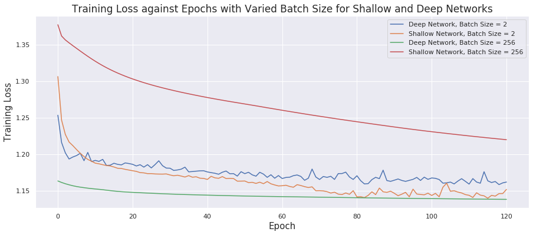

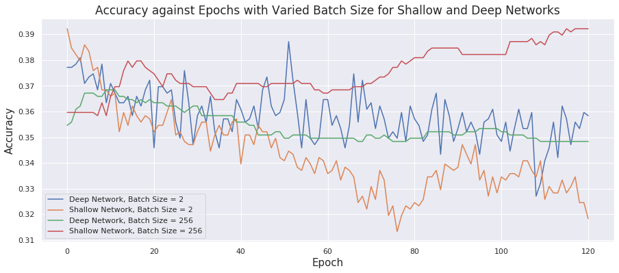

```python
# Plot the loss values against epochs
plot_stats(
    [loss_d4, loss_5, loss_d5, loss_7],
    ['Deep Network, Batch Size = 2',
     'Shallow Network, Batch Size = 2',
     'Deep Network, Batch Size = 256',
     'Shallow Network, Batch Size = 256'
     ],
    'Training Loss against Epochs with Varied Batch Size for Shallow and Deep Networks',
    'Training Loss'
    )

# Plot the accuracies against epochs
plot_stats(
    [accuracies_d4, accuracies_5, accuracies_d5, accuracies_7],
    ['Deep Network, Batch Size = 2',
     'Shallow Network, Batch Size = 2',
     'Deep Network, Batch Size = 256',
     'Shallow Network, Batch Size = 256'
     ],
    'Accuracy against Epochs with Varied Batch Size for Shallow and Deep Networks',
    'Accuracy'
    )
```

The deep network with a small batch size shows interesting behaviour. After an initial decrease the training loss stays relatively stable and the in-sample accuracy doesn't settle into a particular pattern of behaviour. The deep network with high batch size has much more stable accuracy but still not increasing or decreasing consistently.

The largest difference in behaviour is between the deep and shallow networks with a high batch size, with the former having a consistently lower training loss despite the latter achieving higher accuracies.

#### Test Data

Now we'll consider how the base and the deep networks perform with the test data.

Note that we're not using the neural network that has a tuned dropout rate.

```python
# get classification reports and confusion matrices for the shallow neural network
%%time
test_loader = get_test_loader_from_arrays(batch_size_optimal, descriptors_test, target_test)
y_pred_nn_base, _ = neural_network_predict(network_base, test_loader)
class_report_nn_base = classification_report(target_test, y_pred_nn_base, target_names = target_names)
conf_matrix_nn_base = confusion_matrix(target_test, y_pred_nn_base)
```

```
CPU times: user 23 ms, sys: 1.94 ms, total: 24.9 ms
Wall time: 28.4 ms
```

```python
# get classification reports and confusion matrices for the deep neural network
%%time
test_loader_deep = get_test_loader_from_arrays(batch_size_optimal, descriptors_test, target_test)
y_pred_nn_deep, _ = neural_network_predict(network_deep, test_loader_deep)
class_report_nn_deep = classification_report(target_test, y_pred_nn_deep, target_names = target_names)
conf_matrix_nn_deep = confusion_matrix(target_test, y_pred_nn_deep)
```

```
CPU times: user 26.4 ms, sys: 1.06 ms, total: 27.4 ms
Wall time: 31.4 ms
```

```python
print('Classification Report --- Neural Network (Shallow)')
print(class_report_nn_base)
print('Classification Report --- Neural Network (Deep)')
print(class_report_nn_deep)
```

```
Classification Report --- Neural Network (Shallow)
              precision    recall  f1-score   support

Unacceptable       0.64      0.83      0.72       412
  Acceptable       0.48      0.15      0.23       188
        Good       0.43      0.42      0.43       204
   Very Good       0.52      0.54      0.53       188

    accuracy                           0.56       992
   macro avg       0.52      0.49      0.48       992
weighted avg       0.54      0.56      0.53       992

Classification Report --- Neural Network (Deep)
              precision    recall  f1-score   support

Unacceptable       0.75      0.80      0.77       412
  Acceptable       0.46      0.06      0.10       188
        Good       0.40      0.63      0.49       204
   Very Good       0.52      0.56      0.54       188

    accuracy                           0.58       992
   macro avg       0.53      0.51      0.48       992
weighted avg       0.58      0.58      0.54       992
```

Overall, the deep neural network performs slightly better in overall accuracy, and in particular it's precision in classifying unacceptable cars is considerably higher.

However, the issue that we discussed in Task 4 of models having bad recall rates for acceptable cars is exacerbated in the deep neural network. The deep network has a recall score of 0.06 for acceptable cars, meaning that the model is terrible if we want to retrieve as many acceptable cars as possible from the data set. The deep network is doing what the other models are in quickly classifying cars with bad characteristics as unacceptable instead of acceptable, but to a higher degree.

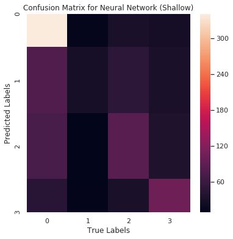

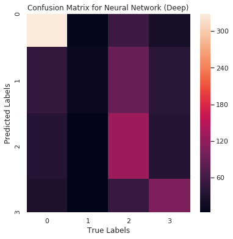

```python
conf_matrix_heatmap(conf_matrix_nn_base, 'Confusion Matrix for Neural Network (Shallow)')
conf_matrix_heatmap(conf_matrix_nn_deep, 'Confusion Matrix for Neural Network (Deep)')
```

The confusion matrices reveal some interesting behaviour in the deep network. We see that the deep neural network is susceptible to rating good cars as acceptable, which is a characteristic that wasn't seen in the other models. To a lesser extent, the model is also giving a lot of good cars to rating of unacceptable. This might show that the deep neural network is better than other models at distinguishing cars with very good characteristics and all other cars.

The only other notable difference between the confusion matrices is that the deep neural network is labelling more good cars as good than the shallow model. This is likely due to the intermediate layers of neurons being able to capture the patterns of good cars better than the shallow network.

Note that the deep network is also taking slightly longer to compute a prediction for the test data.

### Task 5.2 - Sigmoid

```python
# Define the hyperparameters that we're gonna use in the following analysis
hidden_size_s = 200
```

```python
# Define the neural network with sigmoid function
class NeuralNetSM(nn.Module):
    def __init__(self, input_size, hidden_size_s, num_classes, dropout_rate = 0):
        super(NeuralNetSM, self).__init__()

        self.layer1 = nn.Linear(input_size, hidden_size_s)
        self.dropout = nn.Dropout(dropout_rate)
        self.layer2 = nn.Linear(hidden_size_s, hidden_size_s)
        self.layer3 = nn.Linear(hidden_size_s, num_classes)

    def forward(self, x):
        # Use Sigmoid as the activation function
        x = torch.sigmoid(self.layer1(x))
        x = self.dropout(x)
        x = torch.sigmoid(self.layer2(x))
        x = self.layer3(x)
        # No final softmax as it's included in CrossEntropyLoss
        return x
```

```python
# Create instance of the network using sigmoid activation function
network_sm = NeuralNetSM(input_size, hidden_size_s, num_classes)
```

```python
%%time
# Train the network
loss_sm, accuracies_sm, network_sm = neural_network_training(network_sm, print_loss_values = False, split_and_test = True)
```

```
CPU times: user 10.6 s, sys: 253 ms, total: 10.9 s
Wall time: 11 s
```

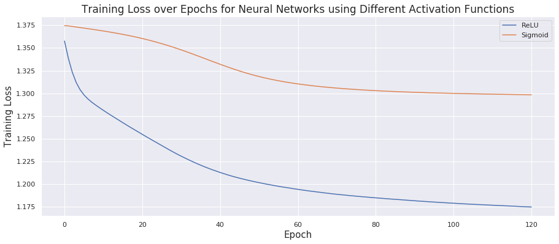

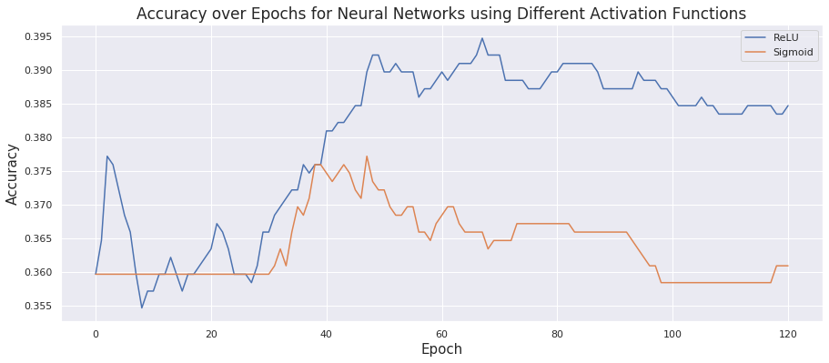

```python
# Plot training loss and accuracy
plot_stats([loss_base, loss_sm], ['ReLU', 'Sigmoid'], 'Training Loss over Epochs for Neural Networks using Different Activation Functions', 'Training Loss')
plot_stats([accuracies_base, accuracies_sm], ['ReLU', 'Sigmoid'], 'Accuracy over Epochs for Neural Networks using Different Activation Functions', 'Accuracy')
```

We can see that using sigmoid as our activation function instead of ReLU leads to much worse performance overall when considering training loss and the accuracy of the model on in-sample data.

The sigmoid model trains differently to the ReLU model for the first 30 epochs, as can be seen by the flat line in the accuracy plot in contrast to the erratic behaviour of the ReLU model. In this period the training loss also decreases less quickly than the ReLU model.

After 30 epochs, the accuracy of the sigmoid model does climb at the same rate as the ReLU model up to about 40 epochs, but then quickly trails off where the ReLU model continues to improve in accuracy.

Overall, the sigmoid model is considerably worse in these metrics than the ReLU model.

Now we consider how it performs with the test data.

```python
# get classification reports and confusion matrices for the sigmoid neural network
%%time
test_loader_sm = get_test_loader_from_arrays(batch_size_optimal, descriptors_test, target_test)
y_pred_nn_sm, _ = neural_network_predict(network_sm, test_loader_sm)
class_report_nn_sm = classification_report(target_test, y_pred_nn_sm, target_names = target_names)
conf_matrix_nn_sm = confusion_matrix(target_test, y_pred_nn_sm)
```

```
CPU times: user 25.1 ms, sys: 19 µs, total: 25.1 ms
Wall time: 32.4 ms
```

```
Classification Report --- Neural Network (Deep)
              precision    recall  f1-score   support

Unacceptable       0.57      0.83      0.67       412
  Acceptable       0.00      0.00      0.00       188
        Good       0.25      0.48      0.32       204
   Very Good       0.00      0.00      0.00       188

    accuracy                           0.44       992
   macro avg       0.20      0.33      0.25       992
weighted avg       0.29      0.44      0.35       992
```

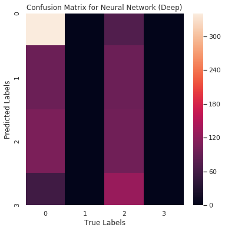

```python
print('Classification Report --- Neural Network (Deep)')
print(class_report_nn_sm)
conf_matrix_heatmap(conf_matrix_nn_sm, 'Confusion Matrix for Neural Network (Deep)')
```

This reveals that the low speed of convergence in the training is an issue if we're to use sigmoid as our activation function, as the network has only got to the point where it can either label cars as unacceptable or as good. The network hasn't been sufficiently trained to the point where it can distinguish more classes and rate cars in the slightly more subtle classes of acceptable or very good.

#### Speed of Convergence

We saw that the sigmoid has a lower speed of convergence than the base network, so now we'll consider the sigmoid model but over a higher number of epochs to see if this changes the performance.

```python
# Create instance of the network using sigmoid activation function
network_sm2 = NeuralNetSM(input_size, hidden_size_s, num_classes)
```

```python
%%time
# Train the network
loss_sm2, accuracies_sm2, network_sm2 = neural_network_training(network_sm2, print_loss_values = False, split_and_test = True, epochs = 480)
```

```
CPU times: user 42.1 s, sys: 983 ms, total: 43.1 s
Wall time: 43.7 s
```

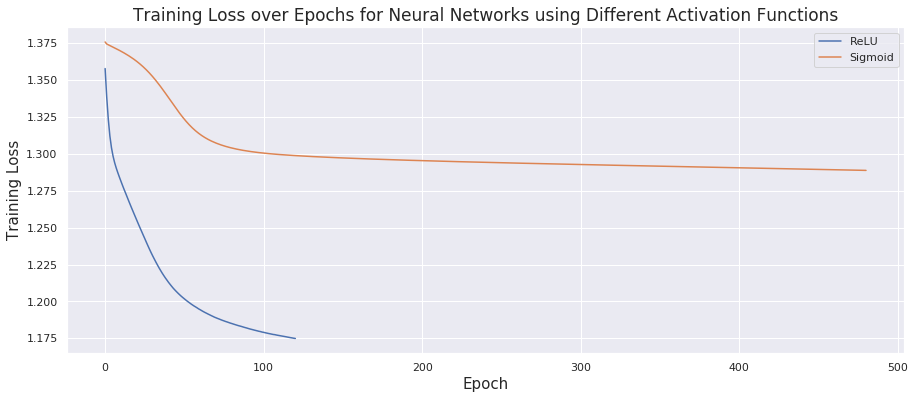

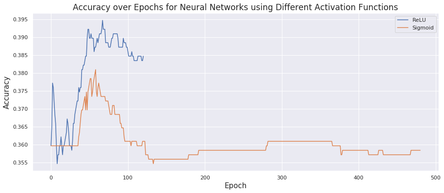

```python
# Plot training loss and accuracy
plot_stats([loss_base, loss_sm2], ['ReLU', 'Sigmoid'], 'Training Loss over Epochs for Neural Networks using Different Activation Functions', 'Training Loss')
plot_stats([accuracies_base, accuracies_sm2], ['ReLU', 'Sigmoid'], 'Accuracy over Epochs for Neural Networks using Different Activation Functions', 'Accuracy')
```

Testing the sigmoid model over a higher number of epochs did not produce an improved outcome, as the training loss does in fact flat-line after 100 epochs, and the accuracy doesn't tend towards any particular value and instead oscillations at around 35.75%.

The sigmoid network after 480 epochs doesn't achieve anywhere near the same level of accuracy that the ReLU model does after a quarter of the time.

So we can conclude in general that the network using sigmoid activation has a much slower convergence rate than the base network.